# From Excel to Python via Pandas: Data acquisition, munging and visualization

## Abhijit Dasgupta ARAASTAT Data Community DC

### adasgupta@araastat.com, abhijit@datacommunitydc.org @webbedfeet

# Snake eating data

Data analysis is Python is based on a stack of packages

- numpy
- scipy
- matplotlib

These were meant as an open-source alternative to **Matlab**

Geared to **numerical** data

# Snake eating data

Most data sets we see are **mixed type**, i.e. mix of numerical, categorical and string

This was a PAIN to deal with (it still is in Matlab)

[figure not shown]

# Snakes eating data

Pandas is a Python data analysis package developed by Wes McKinney in 2008

- Currently at version 0.16
- Well-documented
- http://pandas.pydata.org

## Why use pandas?

- Created right kinds of data structures
  - Mixed type container (**DataFrame**)!!
  - Indexed data structures (refer by name or position)
- Convenient
  - Nice wrappers around most functionality
  - Takes advantage of chained operations

## Why not use pandas?

- Convenient!!
  - Not necessarily most efficient for production
  - Loads all data into memory
  - Requires long time to compile, for use in `virtualenv`

Nice blog by Ben Bengfort on [reading CSV in Python efficiently](https://districtdatalabs.silvrback.com/simple-csv-data-wrangling-with-python)

# Let's get started

```python
import warnings
warnings.filterwarnings("ignore", category=DeprecationWarning)
warnings.filterwarnings("ignore", category=UserWarning)

import numpy as np
import pandas as pd
import matplotlib.pyplot as plt
pd.__version__
```

```
'0.16.0'
```

```python
dat = pd.read_csv('diamonds.csv')
dat.head()
```

|  | carat | cut | color | clarity | depth | table | price | x | y | z |
| --- | --- | --- | --- | --- | --- | --- | --- | --- | --- | --- |
| 0 | 0.23 | Ideal | E | SI2 | 61.5 | 55 | 326 | 3.95 | 3.98 | 2.43 |
| 1 | 0.21 | Premium | E | SI1 | 59.8 | 61 | 326 | 3.89 | 3.84 | 2.31 |
| 2 | 0.23 | Good | E | VS1 | 56.9 | 65 | 327 | 4.05 | 4.07 | 2.31 |
| 3 | 0.29 | Premium | I | VS2 | 62.4 | 58 | 334 | 4.20 | 4.23 | 2.63 |
| 4 | 0.31 | Good | J | SI2 | 63.3 | 58 | 335 | 4.34 | 4.35 | 2.75 |

# Reading data

Pandas can read data using wrappers from

- CSV/TSV
- Excel
- JSON
- HTML
- Stata (.dta)
- Several others

Pandas can write to the formats it reads from

```python
diamonds = pd.read_csv('diamonds.csv')
diamonds.head()
```

|  | carat | cut | color | clarity | depth | table | price | x | y | z |
| --- | --- | --- | --- | --- | --- | --- | --- | --- | --- | --- |
| 0 | 0.23 | Ideal | E | SI2 | 61.5 | 55 | 326 | 3.95 | 3.98 | 2.43 |
| 1 | 0.21 | Premium | E | SI1 | 59.8 | 61 | 326 | 3.89 | 3.84 | 2.31 |
| 2 | 0.23 | Good | E | VS1 | 56.9 | 65 | 327 | 4.05 | 4.07 | 2.31 |
| 3 | 0.29 | Premium | I | VS2 | 62.4 | 58 | 334 | 4.20 | 4.23 | 2.63 |
| 4 | 0.31 | Good | J | SI2 | 63.3 | 58 | 335 | 4.34 | 4.35 | 2.75 |

```python
import sqlite3
con = sqlite3.connect('diamonds.sqlite')

diamonds = pd.read_sql('SELECT * FROM diamonds',con, index_col='index')
diamonds.head()
```

[output not shown]

# Re-naming variables

```python
diamonds = pd.read_csv('diamonds.csv')
diamonds.rename(columns = {'x':'length','y':'width','z':'depth'}, inplace=True)
diamonds.columns.values[4] = 'depthperc'
diamonds.head()
```

|  | carat | cut | color | clarity | depthperc | table | price | length | width | depth |
| --- | --- | --- | --- | --- | --- | --- | --- | --- | --- | --- |
| 0 | 0.23 | Ideal | E | SI2 | 61.5 | 55 | 326 | 3.95 | 3.98 | 2.43 |
| 1 | 0.21 | Premium | E | SI1 | 59.8 | 61 | 326 | 3.89 | 3.84 | 2.31 |
| 2 | 0.23 | Good | E | VS1 | 56.9 | 65 | 327 | 4.05 | 4.07 | 2.31 |
| 3 | 0.29 | Premium | I | VS2 | 62.4 | 58 | 334 | 4.20 | 4.23 | 2.63 |
| 4 | 0.31 | Good | J | SI2 | 63.3 | 58 | 335 | 4.34 | 4.35 | 2.75 |

# Creating new columns

```python
diamonds['cubic'] = diamonds['length']*diamonds['width']*diamonds['depth']
# diamonds['cubic'] = diamonds[['length','width','depth']].product(axis=1)
diamonds['total'] = diamonds.length+diamonds.width+diamonds.depth
# diamonds['total'] = diamonds[['length','width','depth']].sum(axis=1)
#
# diamonds.assign(cubic = diamonds[['length','width','depth']].product(axis=1),
#    total=diamonds[['length','width','depth']].sum(axis=1))

diamonds.head()
```

|  | carat | cut | color | clarity | depthperc | table | price | length | width | depth | cubic | total |
| --- | --- | --- | --- | --- | --- | --- | --- | --- | --- | --- | --- | --- |
| 0 | 0.23 | Ideal | E | SI2 | 61.5 | 55 | 326 | 3.95 | 3.98 | 2.43 | 38.202030 | 10.36 |
| 1 | 0.21 | Premium | E | SI1 | 59.8 | 61 | 326 | 3.89 | 3.84 | 2.31 | 34.505856 | 10.04 |
| 2 | 0.23 | Good | E | VS1 | 56.9 | 65 | 327 | 4.05 | 4.07 | 2.31 | 38.076885 | 10.43 |
| 3 | 0.29 | Premium | I | VS2 | 62.4 | 58 | 334 | 4.20 | 4.23 | 2.63 | 46.724580 | 11.06 |
| 4 | 0.31 | Good | J | SI2 | 63.3 | 58 | 335 | 4.34 | 4.35 | 2.75 | 51.917250 | 11.44 |

# Extracting data

## By label

```python
diamonds.loc[:10, 'color':'price']
```

|  | color | clarity | depthperc | table | price |
| --- | --- | --- | --- | --- | --- |
| 0 | E | SI2 | 61.5 | 55 | 326 |
| 1 | E | SI1 | 59.8 | 61 | 326 |
| 2 | E | VS1 | 56.9 | 65 | 327 |
| 3 | I | VS2 | 62.4 | 58 | 334 |
| 4 | J | SI2 | 63.3 | 58 | 335 |
| 5 | J | VVS2 | 62.8 | 57 | 336 |
| 6 | I | VVS1 | 62.3 | 57 | 336 |
| 7 | H | SI1 | 61.9 | 55 | 337 |
| 8 | E | VS2 | 65.1 | 61 | 337 |
| 9 | H | VS1 | 59.4 | 61 | 338 |
| 10 | J | SI1 | 64.0 | 55 | 339 |

## By position

```python
diamonds.iloc[1:5,:7]
```

|  | carat | cut | color | clarity | depthperc | table | price |
| --- | --- | --- | --- | --- | --- | --- | --- |
| 1 | 0.21 | Premium | E | SI1 | 59.8 | 61 | 326 |
| 2 | 0.23 | Good | E | VS1 | 56.9 | 65 | 327 |
| 3 | 0.29 | Premium | I | VS2 | 62.4 | 58 | 334 |
| 4 | 0.31 | Good | J | SI2 | 63.3 | 58 | 335 |

```python
diamonds.iloc[:,[1]+range(5,12)].mean()
```

```
table       57.457184
price     3932.799722
length       5.731157
width        5.734526
depth        3.538734
cubic      129.849403
total       15.004417
dtype: float64
```

# Missing values

```python
vals = pd.Series([5,3,4,8,2,9], index=['a','b','c','d','e','f'])
vals2 = vals[['a','b','c','f','g','h']]

dat = pd.DataFrame({'orig':vals, 'new':vals2})
dat
```

|  | new | orig |
| --- | --- | --- |
| a | 5 | 5 |
| b | 3 | 3 |
| c | 4 | 4 |
| d | NaN | 8 |
| e | NaN | 2 |
| f | 9 | 9 |
| g | NaN | NaN |
| h | NaN | NaN |

```python
dat.dropna()
```

|  | new | orig |
| --- | --- | --- |
| a | 5 | 5 |
| b | 3 | 3 |
| c | 4 | 4 |
| f | 9 | 9 |

```python
dat.fillna(1)
```

|  | new | orig |
| --- | --- | --- |
| a | 5 | 5 |
| b | 3 | 3 |
| c | 4 | 4 |
| d | 1 | 8 |
| e | 1 | 2 |
| f | 9 | 9 |
| g | 1 | 1 |
| h | 1 | 1 |

```python
dat2=dat.append(dat.loc['a',:])
dat2.index.values[-1] = 'j'
dat2
#dat2.duplicated()
#dat2.drop_duplicates()
```

[output not shown]

# Summaries and aggregation

```python
diamonds.color.value_counts(sort=False)
```

```
D     6775
E     9797
F     9542
G    11292
H     8304
I     5422
J     2808
dtype: int64
```

```python
diamonds.loc[:,['price','cubic']].describe()
```

|  | price | cubic |
| --- | --- | --- |
| count | 53940.000000 | 53940.000000 |
| mean | 3932.799722 | 129.849403 |
| std | 3989.439738 | 78.245262 |
| min | 326.000000 | 0.000000 |
| 25% | 950.000000 | 65.136830 |
| 50% | 2401.000000 | 114.808572 |
| 75% | 5324.250000 | 170.842451 |
| max | 18823.000000 | 3840.598060 |

```python
diamonds.price.mean()
```

```
3932.7997219132371
```

## Split-apply-combine

```python
diamonds.groupby('color')['price'].max()
```

```
color
D    18693
E    18731
F    18791
G    18818
H    18803
I    18823
J    18710
Name: price, dtype: int64
```

```python
newdat=diamonds[['cut','clarity','depthperc','table','price','length','width','depth','cubic']]
newdat.groupby(['cut','clarity']).aggregate(np.mean)
#newdat.groupby(['cut','clarity'], as_index=False).aggregate(np.mean)
```

| cut | clarity | depthperc | table | price | length | width | depth | cubic |
| --- | --- | --- | --- | --- | --- | --- | --- | --- |
| Fair | I1 | 65.699048 | 58.114286 | 3703.533333 | 6.723000 | 6.624238 | 4.386905 | 212.305256 |
|  | IF | 60.066667 | 59.111111 | 1912.333333 | 5.050000 | 5.050000 | 3.033333 | 78.817934 |
|  | SI1 | 63.910294 | 59.126961 | 4208.279412 | 6.127230 | 6.071985 | 3.895711 | 152.090166 |
|  | SI2 | 64.421888 | 58.828326 | 5173.916309 | 6.570343 | 6.503927 | 4.211867 | 189.551704 |
|  | VS1 | 62.945294 | 60.365294 | 4165.141176 | 5.932353 | 5.864059 | 3.709882 | 139.217778 |
|  | VS2 | 63.637548 | 59.050958 | 4174.724138 | 5.966590 | 5.907011 | 3.780230 | 140.820792 |
|  | VVS1 | 60.417647 | 61.235294 | 3871.352941 | 5.503529 | 5.508824 | 3.327647 | 108.225881 |
|  | VVS2 | 62.847826 | 59.237681 | 3349.768116 | 5.495507 | 5.464638 | 3.444058 | 110.607951 |
| Good | I1 | 62.067708 | 59.497917 | 3596.635417 | 6.651562 | 6.614792 | 4.065625 | 189.280797 |
|  | IF | 61.440845 | 59.056338 | 4098.323944 | 5.278310 | 5.315070 | 3.252958 | 100.632368 |
|  | SI1 | 62.696346 | 58.430962 | 3689.533333 | 5.799776 | 5.809974 | 3.635064 | 133.246041 |
|  | SI2 | 62.242831 | 58.924977 | 4580.260870 | 6.272414 | 6.276577 | 3.895245 | 165.503678 |
|  | VS1 | 62.018673 | 58.775772 | 3801.445988 | 5.636852 | 5.657176 | 3.499954 | 122.173289 |
|  | VS2 | 62.363292 | 58.664826 | 4262.236196 | 5.863262 | 5.878395 | 3.658231 | 136.557896 |
|  | VVS1 | 62.123118 | 58.922581 | 2254.774194 | 4.926290 | 4.950806 | 3.068602 | 81.608571 |
|  | VVS2 | 62.311538 | 58.672727 | 3079.108392 | 5.246154 | 5.269406 | 3.273497 | 99.608007 |
| Ideal | I1 | 61.648630 | 56.102740 | 4335.726027 | 6.751712 | 6.736712 | 4.158493 | 200.167470 |
|  | IF | 61.645710 | 55.707013 | 2272.913366 | 4.827261 | 4.850289 | 2.982211 | 75.267679 |
|  | SI1 | 61.737482 | 56.061023 | 3752.118169 | 5.781287 | 5.791226 | 3.570801 | 131.429586 |
|  | SI2 | 61.701001 | 56.120516 | 4755.952656 | 6.262621 | 6.268853 | 3.865889 | 164.958029 |
|  | VS1 | 61.706436 | 55.894037 | 3489.744497 | 5.449746 | 5.470635 | 3.366615 | 111.023001 |
|  | VS2 | 61.730901 | 55.931256 | 3284.550385 | 5.428111 | 5.434484 | 3.352102 | 110.020551 |
|  | VVS1 | 61.679091 | 55.839912 | 2468.129458 | 4.960596 | 4.978012 | 3.064304 | 81.758505 |
|  | VVS2 | 61.690714 | 55.915848 | 3250.290100 | 5.214693 | 5.231869 | 3.221550 | 96.450113 |
| Premium | I1 | 61.183415 | 59.068293 | 3947.331707 | 6.842098 | 6.785902 | 4.130683 | 206.018737 |
|  | IF | 61.047826 | 58.730435 | 3856.143478 | 5.234957 | 5.220870 | 3.191478 | 98.717952 |
|  | SI1 | 61.303329 | 58.758993 | 4455.269371 | 6.045410 | 6.009731 | 3.692162 | 147.378629 |
|  | SI2 | 61.178976 | 58.779654 | 5545.936928 | 6.569495 | 6.543822 | 4.001967 | 186.615917 |
|  | VS1 | 61.318451 | 58.690397 | 4485.462041 | 5.738049 | 5.710935 | 3.509703 | 129.229448 |
|  | VS2 | 61.283408 | 58.754155 | 4550.331248 | 5.834665 | 5.806175 | 3.565639 | 135.472878 |
|  | VVS1 | 61.260877 | 58.674513 | 2831.206169 | 5.037955 | 5.018847 | 3.080000 | 86.888166 |
|  | VVS2 | 61.280230 | 58.654483 | 3795.122989 | 5.390920 | 5.367126 | 3.295920 | 106.808109 |
| Very Good | I1 | 61.755952 | 59.372619 | 4078.226190 | 6.800119 | 6.796071 | 4.197381 | 206.437114 |
|  | IF | 61.363806 | 57.455224 | 4396.216418 | 5.293097 | 5.334403 | 3.259813 | 101.679591 |
|  | SI1 | 61.947222 | 58.014907 | 3932.391049 | 5.869244 | 5.897009 | 3.643451 | 137.203428 |
|  | SI2 | 61.862952 | 58.251571 | 4988.688095 | 6.365814 | 6.391233 | 3.944495 | 172.350489 |
|  | VS1 | 61.729127 | 57.822197 | 3805.353239 | 5.575758 | 5.607448 | 3.467177 | 119.854199 |
|  | VS2 | 61.849247 | 57.958665 | 4215.759552 | 5.769097 | 5.799263 | 3.576144 | 131.600456 |
|  | VVS1 | 61.675919 | 57.622687 | 2459.441065 | 4.895513 | 4.927503 | 3.031420 | 80.881842 |
|  | VVS2 | 61.660972 | 57.712308 | 3037.765182 | 5.083004 | 5.115911 | 3.144348 | 92.420163 |

```python
cars = pd.read_csv('mtcars.csv')
grouped=cars.groupby(['cyl','gear','carb'])
stats = ['count','mean','median']
grouped.agg(stats)[['mpg','disp']]
```

| cyl | gear | carb | mpg count | mpg mean | mpg median | disp count | disp mean | disp median |
| --- | --- | --- | --- | --- | --- | --- | --- | --- |
| 4 | 3 | 1 | 1 | 21.50 | 21.50 | 1 | 120.10 | 120.10 |
|  | 4 | 1 | 4 | 29.10 | 29.85 | 4 | 84.20 | 78.85 |
|  |  | 2 | 4 | 24.75 | 23.60 | 4 | 121.05 | 130.90 |
|  | 5 | 2 | 2 | 28.20 | 28.20 | 2 | 107.70 | 107.70 |
| 6 | 3 | 1 | 2 | 19.75 | 19.75 | 2 | 241.50 | 241.50 |
|  | 4 | 4 | 4 | 19.75 | 20.10 | 4 | 163.80 | 163.80 |
|  | 5 | 6 | 1 | 19.70 | 19.70 | 1 | 145.00 | 145.00 |
| 8 | 3 | 2 | 4 | 17.15 | 17.10 | 4 | 345.50 | 339.00 |
|  |  | 3 | 3 | 16.30 | 16.40 | 3 | 275.80 | 275.80 |
|  |  | 4 | 5 | 12.62 | 13.30 | 5 | 416.40 | 440.00 |
|  | 5 | 4 | 1 | 15.80 | 15.80 | 1 | 351.00 | 351.00 |
|  |  | 8 | 1 | 15.00 | 15.00 | 1 | 301.00 | 301.00 |

```python
diamonds['carat2'] = np.round(diamonds.carat/0.25)*0.25
Summary = (
    diamonds[['cut','color','clarity','carat2','depthperc',
              'table','price','length','width','depth','cubic']]
    .groupby(['cut','color','clarity','carat2'],as_index=False)
    .aggregate(np.mean) # Does means of the rest
    )
Summary.head()
```

|  | cut | color | clarity | carat2 | depthperc | table | price | length | width | depth | cubic |
| --- | --- | --- | --- | --- | --- | --- | --- | --- | --- | --- | --- |
| 0 | Fair | D | I1 | 1.00 | 66.20 | 57 | 2491 | 6.000 | 5.94 | 3.950 | 140.778000 |
| 1 | Fair | D | I1 | 1.50 | 64.70 | 62 | 5460 | 7.190 | 7.04 | 4.600 | 232.840960 |
| 2 | Fair | D | I1 | 1.75 | 64.70 | 56 | 5617 | 7.460 | 7.37 | 4.800 | 263.904960 |
| 3 | Fair | D | I1 | 3.50 | 66.80 | 52 | 15964 | 9.420 | 9.34 | 6.270 | 551.652156 |
| 4 | Fair | D | IF | 0.25 | 60.85 | 57 | 1324 | 4.575 | 4.54 | 2.775 | 57.834823 |

# Pivot tables

```python
PT = pd.pivot_table(diamonds[['color','clarity','price']],
                    index='color',
                    columns = 'clarity',
                    aggfunc = np.mean)
PT
```

| clarity color | price I1 | price IF | price SI1 | price SI2 | price VS1 | price VS2 | price VVS1 | price VVS2 |
| --- | --- | --- | --- | --- | --- | --- | --- | --- |
| D | 3863.023810 | 8307.369863 | 2976.146423 | 3931.101460 | 3030.158865 | 2587.225692 | 2947.912698 | 3351.128391 |
| E | 3488.421569 | 3668.506329 | 3161.838005 | 4173.826036 | 2856.294301 | 2750.941700 | 2219.820122 | 2499.674067 |
| F | 3342.181818 | 2750.836364 | 3714.225716 | 4472.625233 | 3796.717742 | 3756.795093 | 2804.276567 | 3475.512821 |
| G | 3545.693333 | 2558.033774 | 3774.787449 | 5021.684109 | 4131.362197 | 4416.256498 | 2866.820821 | 3845.283437 |
| H | 4453.413580 | 2287.869565 | 5032.414945 | 6099.895074 | 3780.688623 | 4722.414486 | 1845.658120 | 2649.067434 |
| I | 4302.184783 | 1994.937063 | 5355.019663 | 7002.649123 | 4633.183992 | 5690.505560 | 2034.861972 | 2968.232877 |
| J | 5254.060000 | 3363.882353 | 5186.048000 | 6520.958246 | 4884.461255 | 5311.058824 | 4034.175676 | 5142.396947 |

# Vlookups

```python
Summary.rename(columns = {'price':'avgprice'}, inplace=True)
# Summary.head()
VL = pd.merge(diamonds, Summary[['cut','color','clarity','carat2','avgprice']],
              on = ['cut','color','clarity','carat2'])
VL.head()
```

|  | carat | cut | color | clarity | depthperc | table | price | length | width | depth | cubic | total | carat2 | avgprice |
| --- | --- | --- | --- | --- | --- | --- | --- | --- | --- | --- | --- | --- | --- | --- |
| 0 | 0.23 | Ideal | E | SI2 | 61.5 | 55 | 326 | 3.95 | 3.98 | 2.43 | 38.202030 | 10.36 | 0.25 | 484.028571 |
| 1 | 0.31 | Ideal | E | SI2 | 61.7 | 56 | 558 | 4.40 | 4.35 | 2.70 | 51.678000 | 11.45 | 0.25 | 484.028571 |
| 2 | 0.31 | Ideal | E | SI2 | 60.1 | 57 | 558 | 4.44 | 4.41 | 2.66 | 52.083864 | 11.51 | 0.25 | 484.028571 |
| 3 | 0.31 | Ideal | E | SI2 | 61.3 | 55 | 558 | 4.37 | 4.34 | 2.67 | 50.638686 | 11.38 | 0.25 | 484.028571 |
| 4 | 0.32 | Ideal | E | SI2 | 62.0 | 55 | 576 | 4.41 | 4.36 | 2.72 | 52.299072 | 11.49 | 0.25 | 484.028571 |

# Conditioning

```python
diamonds[diamonds.cut=='Ideal'].price.describe()
```

```
count    21551.000000
mean      3457.541970
std       3808.401172
min        326.000000
25%        878.000000
50%       1810.000000
75%       4678.500000
max      18806.000000
Name: price, dtype: float64
```

```python
diamonds[diamonds.price > 1000].cut.value_counts()
```

```
Ideal        14700
Premium      10587
Very Good     8836
Good          3794
Fair          1499
dtype: int64
```

```python
diamonds['Size'] = 'Small'
diamonds.loc[diamonds['carat']>= 0.5, 'Size'] = 'Medium'
diamonds.loc[diamonds['carat'] > 1, 'Size'] = 'Large'
diamonds['Size'] = pd.Categorical(diamonds['Size'],
    categories = ['Small','Medium','Large'])
diamonds.head()
```

|  | carat | cut | color | clarity | depthperc | table | price | length | width | depth | cubic | total | carat2 | Size |
| --- | --- | --- | --- | --- | --- | --- | --- | --- | --- | --- | --- | --- | --- | --- |
| 0 | 0.23 | Ideal | E | SI2 | 61.5 | 55 | 326 | 3.95 | 3.98 | 2.43 | 38.202030 | 10.36 | 0.25 | Small |
| 1 | 0.21 | Premium | E | SI1 | 59.8 | 61 | 326 | 3.89 | 3.84 | 2.31 | 34.505856 | 10.04 | 0.25 | Small |
| 2 | 0.23 | Good | E | VS1 | 56.9 | 65 | 327 | 4.05 | 4.07 | 2.31 | 38.076885 | 10.43 | 0.25 | Small |
| 3 | 0.29 | Premium | I | VS2 | 62.4 | 58 | 334 | 4.20 | 4.23 | 2.63 | 46.724580 | 11.06 | 0.25 | Small |
| 4 | 0.31 | Good | J | SI2 | 63.3 | 58 | 335 | 4.34 | 4.35 | 2.75 | 51.917250 | 11.44 | 0.25 | Small |

# Charts

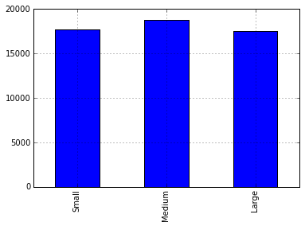

```python
%matplotlib inline
x = diamonds['Size'].value_counts(sort=False)
x.plot(kind='bar');
```

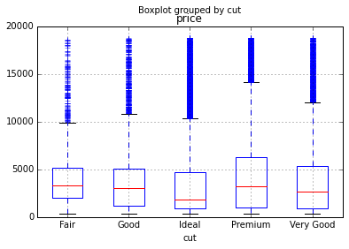

```python
diamonds.boxplot(column = 'price', by='cut');
```

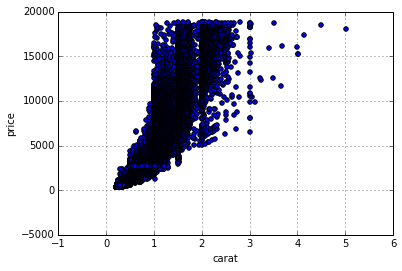

```python
diamonds.plot(kind='scatter', x='carat',y='price');
```

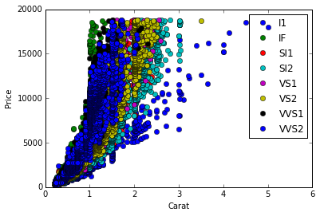

```python
groups = diamonds.groupby('clarity')
fig, ax = plt.subplots();
for name, group in groups:
    ax.plot(group.carat, group.price, marker='o', linestyle='', label=name)
ax.legend(numpoints=1)
plt.xlabel('Carat');
plt.ylabel('Price');
```

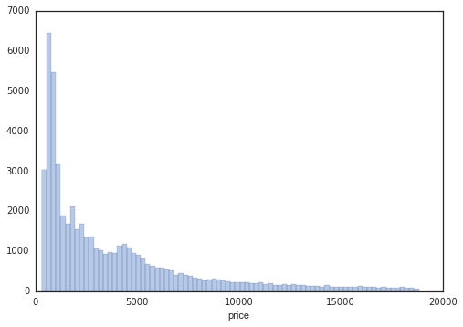

```python
import seaborn as sns
sns.set(style='white', palette='muted')
sns.distplot(diamonds['price'], kde=False);
```

There are several new and nicer graphics libraries available

- Seaborn
- ggplot
- The plot.ly API